# Final Paper

STOR 320.02 Group 4

April 26, 2022

# INTRODUCTION

> As technology evolves, many industries have had to learn how to adapt to a constantly changing market. With the growth of online booking and travel agencies, the hospitality industry had to change its approach with customers as they now have more options than they did in the past. Up until recently, most hotels operated on a cost-based pricing strategy, which meant their prices changed respectively with that of their competitors. However, in today’s society, to stay competitive, more and more hotels are adopting dynamic pricing models, which offer a more flexible approach to pricing due to costs fluctuating within the market. The key to maximizing revenue for hotels is to employ efficient business models that account for numerous dynamic variables. Although many hotels do not have the knowledge or infrastructure to manage dynamic pricing, our analysis aims to help them establish trends that will aid the development of a strong pricing model with a wider spread of applications in the future.

> To make the most out of the data, we first decided to question how different variables influence revenue, or more specifically, Average Daily Rate (ADR). ADR measures the average revenue per booking, per night. Generally, a higher ADR signifies higher revenue and profits, so it is in our best interest to observe the influences on this variable. If we can find the roots of ADR fluctuations, we will be able to design a dynamic pricing model that maximizes revenue.

> We then decided to work with cancellations of bookings, because a hotel oftentimes may not have enough time to resell a canceled room or may need to sell it at a lower price which would not help them maximize revenue. Therefore, attempting to predict if someone would potentially cancel could mitigate the losses incurred from last-minute cancellations. Our goal is to find what variables correlate the most with cancellations. Predicting if someone will cancel could mitigate the losses incurred from last-minute cancellations. This brings us to our second question, wherein we investigated which variables were most effective at predicting cancellations.

# DATA

> Our dataset originates from an article in the academic journal Data in Brief written by Antonio Nuno, Ana de Almeida, and Luis Nunes. The journal details how the data was compiled and its value. The data was acquired from two hotels, a city hotel and a resort. The hotels are located in Lisbon and Algarve, Portugal, respectively. The dataset is quite large, with 119,390 observations, each representing a booking. There are over 30 variables, which we narrowed down to the most relevant and combined some for ease.

> We kept the following variables as-is: is_canceled indicated whether are booking was canceled (1) or not (0); lead_time is the number of days between the entering of the booking into the hotel management system and the arrival date; year and month are the year and month of arrival; previous_cancellations is the number of bookings a particular customer has canceled in the past; booking_changes is the number of changes made to booking from the moment it enters the hotel management system to the moment of check-in or cancelation; ADR is the average revenue per room on a given day; required_car_parking_spaces is the number of parking spaces required by the customer.

> To adequately answer our questions, we changed a few variables. Deposit_type, previously a character variable, is now displayed by numbers. 0 for no deposit (no deposit was made), 1 for non-refundable (a deposit made in the value of the total cost of the stay or above), and 2 for refundable (a deposit made in a value under the total cost of the stay). Hotel was changed to numeric representation as well. 0 for the resort hotel and 1 for the city hotel. Next, we created two new variables. The first variable Duration_of_stay is weekend night stay-ins (number of weekend nights the guest stayed or booked to stay) + weekday night stay-ins (number of weekday nights the guest stayed or booked to stay). The other variable being group_size which combines the variables children, adults, and babies together to get the total number of guests under one reservation.

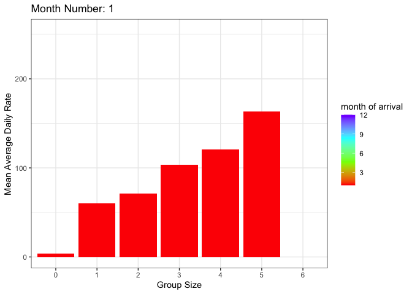

> In investigation of question two we found a possibly misleading statistic due to the accuracy and collection of the deposit_type variable. The variable was defined in terms of three categories: ”No Deposit”, “Non Refund” and “Refundable.” The issue lies within the latter two categories. The original description for this variable claimed that the “Non Refund” category meant that a deposit was made in the value of the total cost of staying, while the other “Refundable” category claimed that it meant a deposit was made with a value under the total cost of staying.

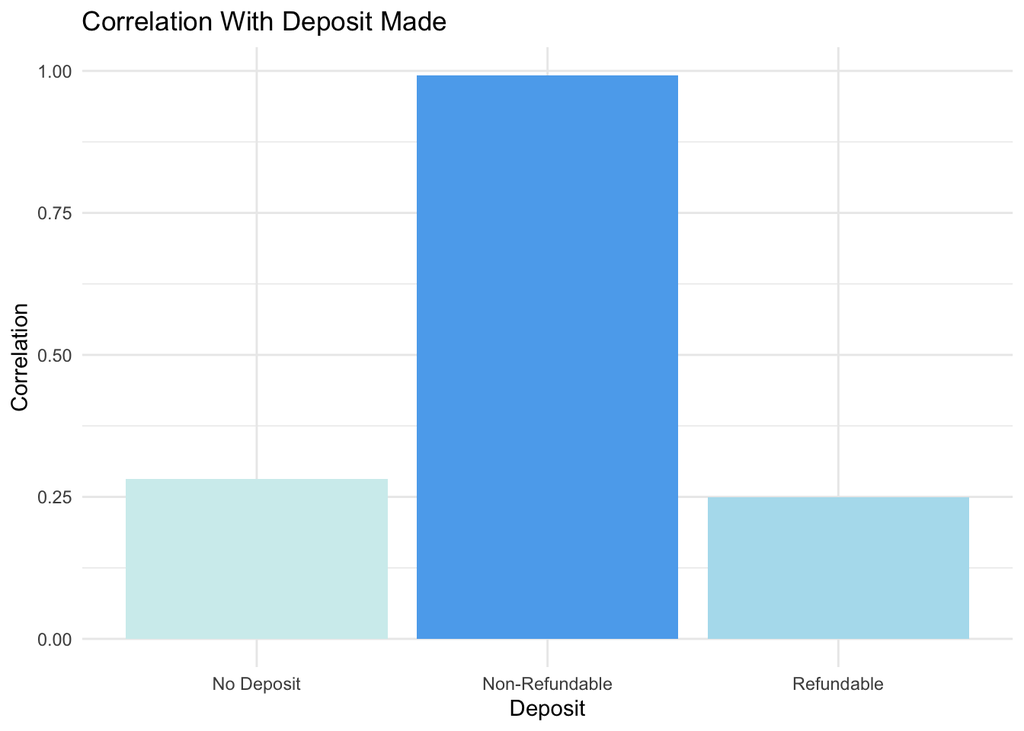

> This contradicts the general meaning of refundable and non-refundable deposits because by definition, refundable deposits means the deposited amount can be returned to the customer regardless of how much it is, and inversely, non refundable deposits means the cost cannot be returned to the customer regardless of it being the full amount or just a portion of the full cost. In most cases, refundable deposits are higher amounts and non refundable deposits are lower amounts, a common theme amongst hotels. However, the original data seems to have a misconception on what the words mean and they do not clearly define the two categories either, so that led us to question the accuracy of the deposit_type variable. We further examine this in the methodology for question two.

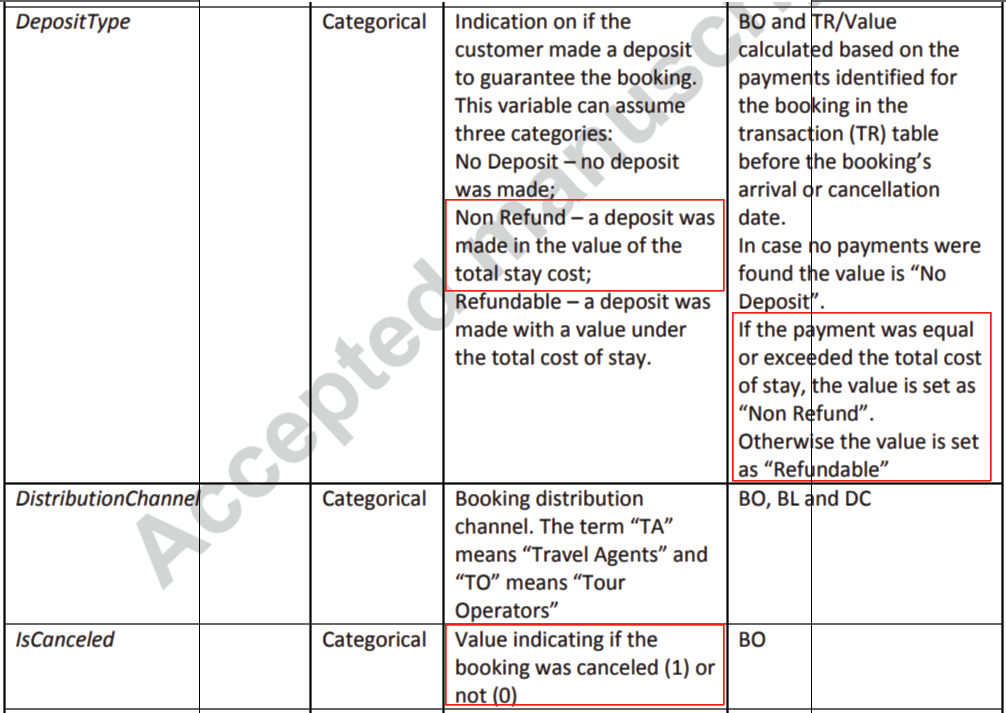

Ratios of Canceled and Not Canceled

| Cancellation Status | Non-Refundable | Percentage | Full Data | Percentage |
| --- | --- | --- | --- | --- |
| Not Canceled | 92 | 0.63% | 72479 | 62.37% |
| Canceled | 14462 | 99.37% | 43721 | 37.63% |

# RESULTS

> **Question 1**

> To see which variables have the greatest positive influence on ADR we first created predictive models. To do this, we made an empty matrix, created a subset of the data frame that compared ADR with all the other variables and added predictions. With the models we created we compared mean absolute error between all the other variables with ADR.

| Variable | MAE |
| --- | --- |
| Rate | 34.4975735599529 |
| Type | 34.0965891521172 |
| Lead | 34.2844393017725 |
| Month | 29.888547156985 |
| Day | 34.4802692295193 |
| Country | 33.508751109407 |
| Room | 32.3959193156505 |
| Weeknights | 34.4879574818912 |
| Weekdays | 34.4498071820558 |
| Adults | 33.1342102761823 |
| Children | 32.4233391744093 |
| Babies | 34.4770685978222 |
| Year | 33.6182854839163 |
| Guests | 31.4186023067303 |
| Days | 34.4538408877539 |
| country | 33.5087511094052 |

> We searched for the variable with the lowest mean absolute error as it meant the predictive model was off by a smaller number. Month had the lowest mean absolute error of 29.89, meaning on average we can expect the model to be off by $29-30. To investigate further we plotted month against ADR by grouping the data by month and year and then averaging the ADR. The results revealed July and August to have the highest average ADR, thus we can conclude the summer months have the greatest positive influence.

[figure not shown]

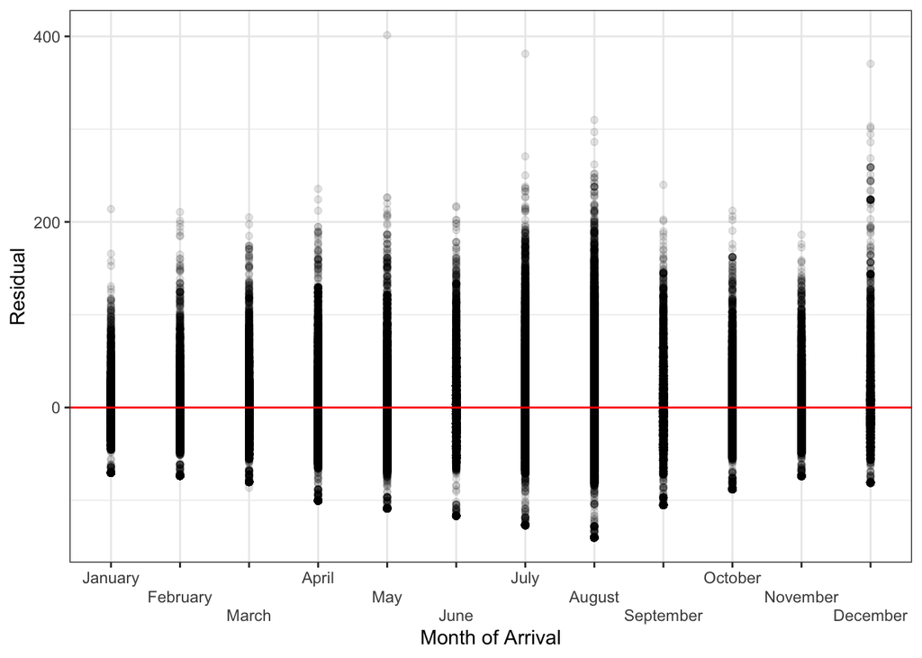

> **Question 2**

> Unlike ADR, our second question of determining which variables are important in predicting whether a reservation will cancel or not involves trying to predict a binary variable of either canceled or not canceled. As a result, we felt that using the k-nearest neighbors method of analysis would be the most efficient way to come to a conclusion. We decided to reformulate our data to achieve this process in two ways. First, we modified the variables of interest for the question. Second, we had to take the remaining character variables and convert them to numerical values for the purposes of correlation. For example, the column for hotel type only contains “Resort Hotel” and “City Hotel”, which can be converted to 0 and 1 values respectively. Our modifications resulted in 11 variables from the data, including whether or not the booking was canceled.

Filtered and Formatted Data

| Canceled | Type | Lead | Month | Guests | Days | Rate | Deposit | Cars | Cancellations | Changes |
| --- | --- | --- | --- | --- | --- | --- | --- | --- | --- | --- |
| 0 | 0 | 14 | 11 | 2 | 2 | 98.0 | 0 | 0 | 0 | 0 |
| 0 | 0 | 14 | 11 | 2 | 2 | 98.0 | 0 | 0 | 0 | 0 |
| 0 | 0 | 0 | 11 | 2 | 2 | 107.0 | 0 | 0 | 0 | 0 |
| 0 | 0 | 9 | 11 | 2 | 2 | 103.0 | 0 | 0 | 0 | 0 |
| 1 | 0 | 85 | 11 | 2 | 3 | 82.0 | 0 | 0 | 0 | 0 |
| 1 | 0 | 75 | 11 | 2 | 3 | 105.5 | 0 | 0 | 0 | 0 |
| 1 | 0 | 23 | 11 | 2 | 4 | 123.0 | 0 | 0 | 0 | 0 |
| 0 | 0 | 35 | 11 | 2 | 4 | 145.0 | 0 | 0 | 0 | 0 |

> Now that the data is properly formatted, we decided to perform an initial investigation with a correlation plot. It seemed appropriate to do an initial evaluation to determine the best variables to keep prior to the k-nearest neighbors analysis as we do have more than a handful of predictor variables. Placing them into a correlation matrix shows that month of stay, days stayed, number of guests, and ADR had very weak correlations to whether or not a guest cancels. As a result, we felt it was appropriate to remove these variables from our continued exploration.

> With the remaining variables in mind, we decided to visualize the data by modeling each individual variable with the Canceled variable to see if their relationships were noticeable and reasonable. We used general linear models for variables like Lead that are effectively continuous. For the discrete variables, we used bar graphs like the one for Deposit in the data section. Almost all of the plots ended up showing significant correlation. Therefore, upon further analysis, we noticed that people who reserved in advance and people who have previously canceled are more likely to cancel. On the other hand, people who make booking changes, and people who are taking their cars are more likely to keep their booking. Although there were cancellations at both hotel locations, cancellations were significantly more likely for the city hotel.

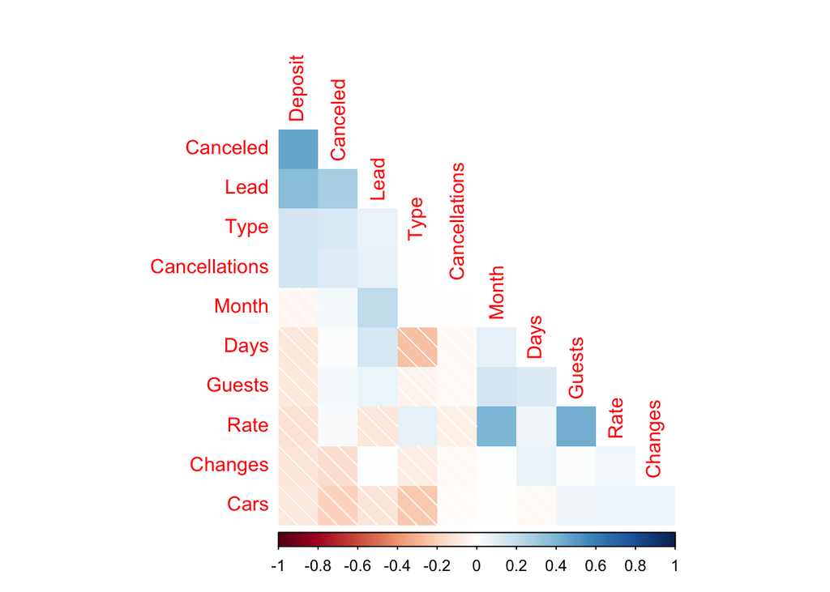

> From the initial plotting, the only outlier involved the Deposit variable which had the highest correlation by a significant margin. However, as previously mentioned, there exists a potentially misleading statistic due to the accuracy and collection process of the Deposit variable that could potentially impact the validity of our findings. Therefore, rather than making a judgment on whether the variable should remain included solely based off the correlation, we decided to proceed by creating four unique “versions” of the data: one completely unchanged, one with the deposit variable removed as a predictor, one with the deposit variable as a binary variable (either Deposit or No Deposit instead of distinguishing between refundable and non-refundable), and a final set with all of the non-refundable observations removed from the data.

> Since the four different versions have been established, we decided to run a program to run through k-nearest neighbor cross validation for each version of the data to see the differences in optimal accuracy and k-values. In order to do this, we had to make two compromises with the process. First, we split the data for each version into a train set and a test set. Since this process involves a function that loops through all combinations of the data potentially hundreds of times, having R do that for over 100,000 observations became too cumbersome. Second, we had initially decided on testing for k-values between 1 and 300, but after seeing the results for the unchanged data and the deposit variable removed data it became clear that anything over 100 was unnecessary. As a result, we kept our range between 1:100 for the sake of efficiency.

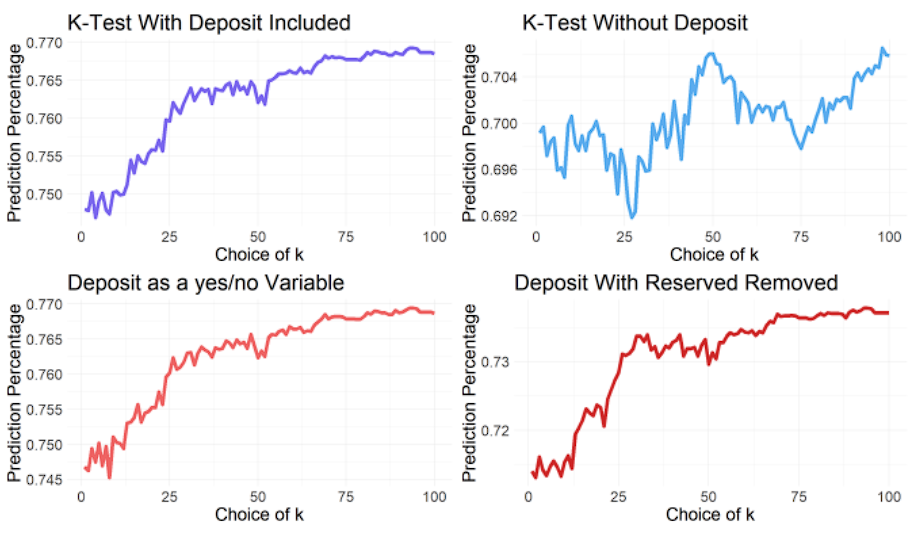

> The initial results from the cross-validation revealed a few key differences between the four versions we investigated. The version with all the data kept and the data with both deposit types combined remained roughly equivalent, both with optimal k-values of 93 and accuracy just short of 77%. The version with the questionable deposit data removed also had an optimal k-value of 93, but the accuracy percentage was reduced to 74. The lowest was the version with no deposit data at all, which had an optimal k-value of 98 and an accuracy percentage of 70.65%. We then attempted to refine the model to see if any of the variables in the model could be removed without affecting accuracy, but after multiple attempts, it seemed like all of the variables were making an active contribution to the accuracy. The highest accuracy percentage for 2 variables was with **Lead** and **Deposit**, but it came out to around 60% accuracy which is a very significant decrease. In order to achieve an accurate interpretation of this data, we decided to use a confusion matrix to determine the correct predictions for each version of the data for both the train and test sets. After finding the proper numbers from the confusion matrix, we used it to calculate specificity, sensitivity, false-positive rate, and false-negative rate. Overall, combining the types of deposits together seemed to have a minimal impact on the accuracy of the model. However, when looking at the false positive/negative rates, an interesting trend occurs that raises questions as to the “best” version of the model. Removing **Deposit** as a variable lowers the accuracy overall and increases the false-negative rate, but it does make the false positive rate lower by 6% without including questionable data. As a result, both the full model and the model with **Deposit** removed have a similar amount of viability for different reasons.

Confusion Matrix Results

| Data Option | True No | False No | True Yes | False Yes | Sensitivity | Specificity | FNR | FPR |
| --- | --- | --- | --- | --- | --- | --- | --- | --- |
| Train All Deposit | 34738 | 1284 | 9524 | 12295 | 43.65% | 96.44% | 3.56% | 56.35% |
| Train No Deposit | 31165 | 4857 | 10889 | 10930 | 49.91% | 86.52% | 13.48% | 50.09% |
| Train Combined | 34724 | 1298 | 9531 | 12288 | 43.68% | 96.40% | 3.60% | 56.32% |
| Train N-R Removed | 34756 | 1229 | 2452 | 12157 | 16.78% | 96.58% | 3.42% | 83.22% |
| Test All Deposit | 33962 | 1461 | 9398 | 11997 | 43.93% | 95.88% | 4.12% | 56.07% |
| Test No Deposit | 30592 | 4831 | 10677 | 10718 | 49.90% | 86.36% | 13.64% | 50.10% |
| Test Combined | 33964 | 1459 | 9406 | 11989 | 43.96% | 95.88% | 4.12% | 56.04% |
| Test N-R Removed | 34014 | 1362 | 2509 | 11837 | 17.49% | 96.15% | 3.85% | 82.51% |

# CONCLUSION

> In our analysis, we attempted to answer two important questions about our dataset. First off, we wanted to determine which variables have the largest effect on ADR by creating prediction models and it turns out the variable Month has the greatest impact on ADR so we looked into what months impacted ADR the most. Upon further investigation, the findings revealed that July and August had the highest average ADR, implying that the summer months have the greatest positive influence on ADR.

> For our second question regarding models for accurately predicting cancellations, we ended up with two competing models that each offer their own benefits and drawbacks. One model is more accurate overall, but it includes an additional predictor variable and the information related to that predictor variable is concerning based on our research. The other model is less accurate overall, but has fewer predictor variables and has a higher incidence of predicting a cancellation when the guest actually canceled in the full data. However, both models have an overall accuracy rating of over 70%, which is within the range of being statistically significant.

> Hoteling is an extremely large industry that relies heavily on statistical analysis to make important decisions about the direction of the business, and as a result it is important to find statistical models that are relevant and reliable. Hotels will always be interested in how much they can charge a guest and how often reservations will actually keep their booking, so our lines of questioning were practical for a real-world environment. While neither of our models were fully accurate, they still serve as solid foundations for further inquiry.

> In regards to further inquiry, there are several key areas of interest that could verify the relevance and accuracy of our models. Primarily, we would like to have clarification on the questionable deposit type data. If the data is accurate then the extremely high percentage of cancellations is a statistically surprising and relevant result, and if the data is inaccurate then it changes the bounds for how we would select our second model. In addition, the timeframe of the dataset is a bit too small to have solid data for changes over time. It runs from mid 2015 to mid 2017, but data into 2022 would offer more insight into any time-based analysis. It would also be beneficial to have more columns of data related to demographics. Although we already have around a dozen potentially relevant columns of data, the only demographic data points we have are a general range of age (adults, children, and babies) and country. When attempting to predict what individuals would do, demographic information can be extremely valuable. Finally, we would like to receive similar data from a different hotel or chain. This would allow us to test our models against hotels that cater to different types of customers, and the results could show if our models are in line with general trends or if they are specific to these two hotels.